# Homework 3

Diana Rueda

10/15/2021

## Problem 2

The glacial varve record plotted in Figure 3.9 exhibits some nonstationarity that can be improved by transforming to logarithms and some additional nonstationarity that can be corrected by differencing the logarithms.

#### (a) Argue that the glacial varves series, say 𝑋𝑡, exhibits heteroscedasticity by computing the sample variance over the first half and the second half of the data. Argue that the transformation 𝑌𝑡=𝑙𝑜𝑔(𝑋𝑡) stabilizes the variance over the series.

Plot the histograms of 𝑋𝑡 and 𝑌𝑡 to see whether the approximation to normality is improved by transforming the data.

```r
library('astsa')
varve_firsthalf = varve[1:317]
varve_secondhalf = varve[318:634]
#compute sample variance on the first half of the data
var(varve_firsthalf)
```

```
## [1] 133.4574
```

```r
#compute sample variance on the second half of the data
var(varve_secondhalf)
```

```
## [1] 594.4904
```

```r
logvarve_firsthalf = log(varve[1:317])
logvarve_secondhalf = log(varve[318:634])
#compute sample variance on the first half of the data
var(logvarve_firsthalf)
```

```
## [1] 0.2707217
```

```r
#compute sample variance on the second half of the data
var(logvarve_secondhalf)
```

```
## [1] 0.451371
```

The glacial varves series shows heteroscedasticity in the comparison of the variance on the first half of the data and the second half of the data. These two variances are significantly different with the variance of the first half at 133.4574 and the variance of the second half at 594.4904.  
Fortunatly the log transformation on X_t stabalizes the variance over the series. If we now compute the variance of the first half of the data and compare it to the variance of the second half of the data we obtain 0.2707217 against 0.451371 in the second half which is considerably more stable than the variance in the original data.

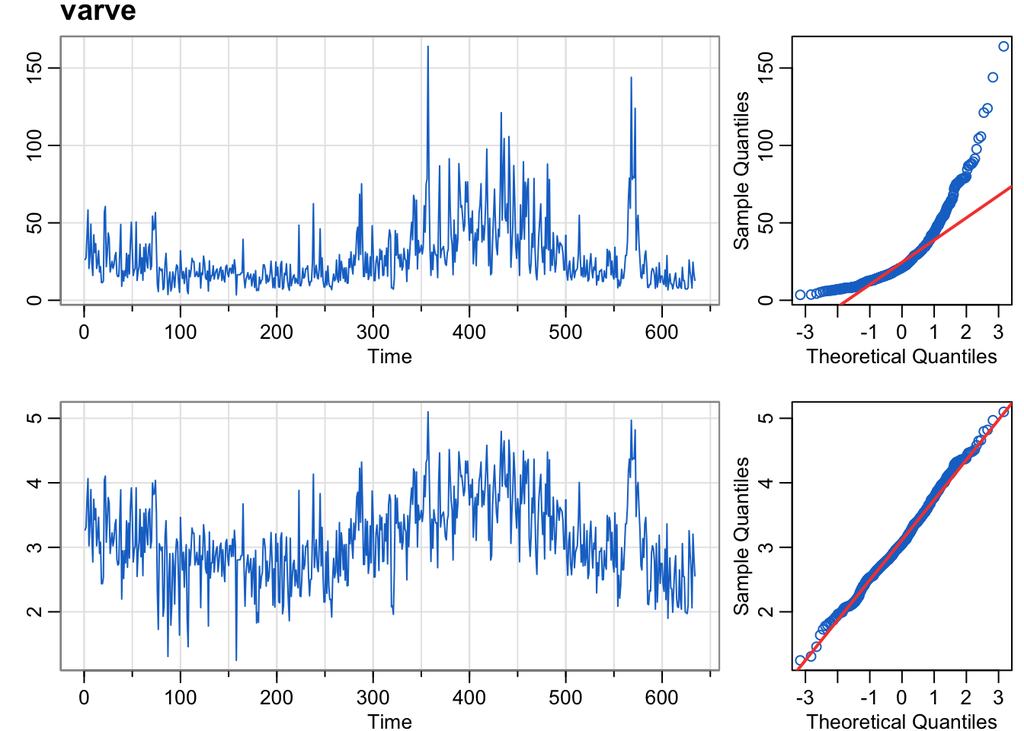

```r
layout(matrix(1:4,2), widths = c(2.5,1))
par(mgp = c(1.6,0.6,0), mar = c(2,2,0.5,0)+0.5)
tsplot(varve, main = "", ylab = "",col = 4, margin = 0)
mtext("varve", side = 3, line = 0.5, cex = 1.2, font = 2, adj = 0)
tsplot(log(varve), main = "", ylab = "", col = 4, margin = 0)
mtext("log(varve)", side = 3, line = 0.5, cex = 1.2, font = 2, adj = 9)

qqnorm(varve, main = "", col = 4); qqline(varve, col = 2, lwd = 2)
qqnorm(log(varve), main = "", col = 4); qqline(log(varve), col = 2, lwd = 2)
```

with the help of these plots we can confirm that the approximation to normality is improved by transforming the data.

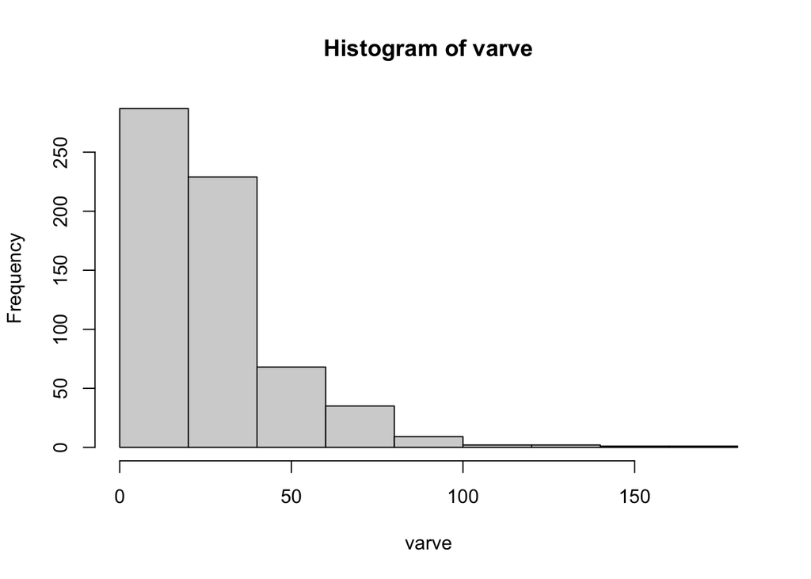

```r
hist(varve)
```

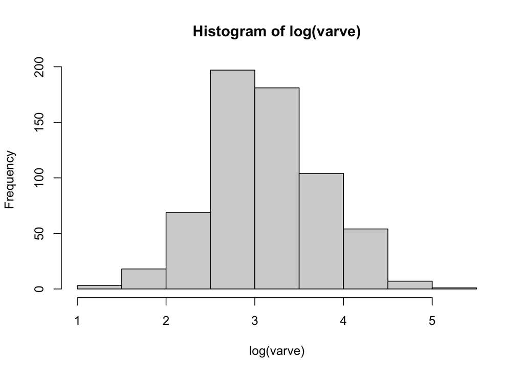

```r
hist(log(varve))
```

#### (b) Plot the series 𝑌𝑡. Do any time intervals, of the order 100 years, exist where one can observe behavior comparable to that observed in the global temperature records in Figure 1.2 (page 3 of the textbook)?

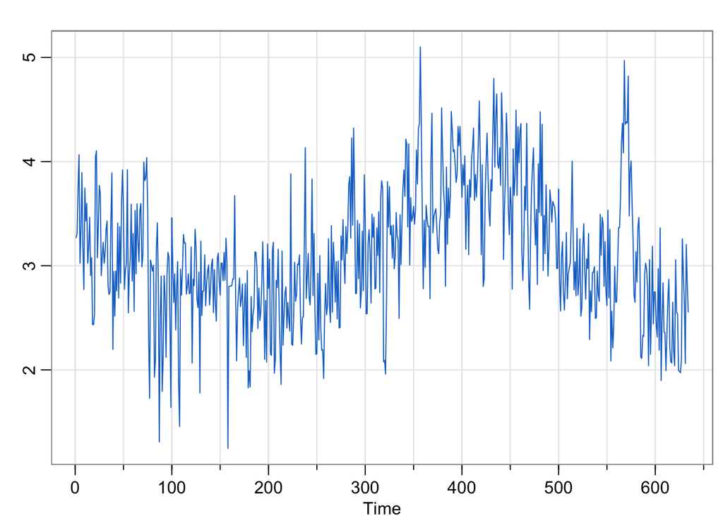

```r
#layout(matrix(1:2,2), widths = c(2.5,1))
tsplot(log(varve), main = "", ylab = "", col = 4, margin = 0)
mtext("log(varve)", side = 3, line = 0.5, cex = 1.2, font = 2, adj = 9)
```

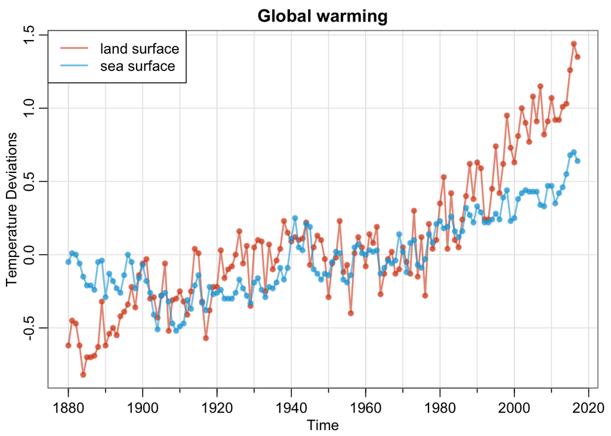

```r
culer = c(rgb(.85,.30,.12,.6), rgb(.12,.65,.85,.6))
tsplot(gtemp_land, col = culer[1], lwd = 2, type = "o", pch = 20, ylab = "Temperature Deviations", main = "Global warming")
lines(gtemp_ocean, col = culer[2], lwd = 2, type = "o", pch = 20)
legend("topleft", col = culer, lty = 1, lwd = 2, legend = c("land surface", "sea surface"), bg = "white")
```

In the plot with the log transformation of the data we can see that the time intervals [200:300] and [300:400] show an increase that resembles the general upward trend of the observed behavior in global temperature records.

### (c) Examine the sample ACF of 𝑌𝑡 and comment

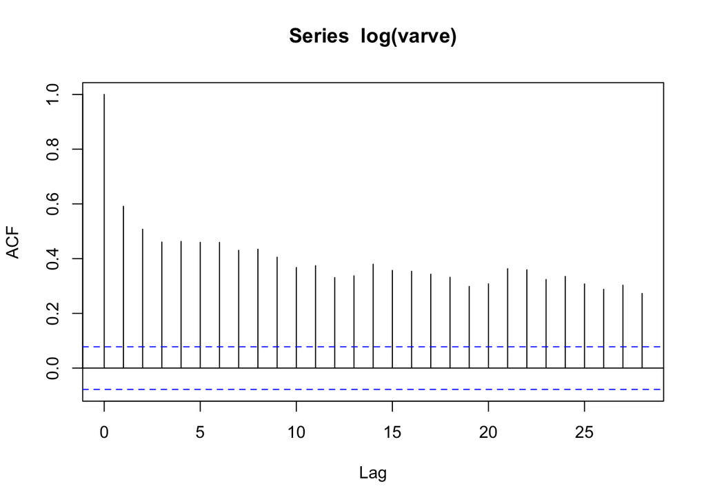

```r
acf(log(varve))
```

From the ACF plot we can observe non-stationary behavior since the values go well above the interval. Thus the log transformation helps stebalize the series but there is still more that could be done.

#### (d) Compute the difference 𝑈𝑡=𝑌𝑡−𝑌𝑡−1, examine its time plot and sample ACF, and argue that differencing the logged varve data produces a reasonably stationary series.

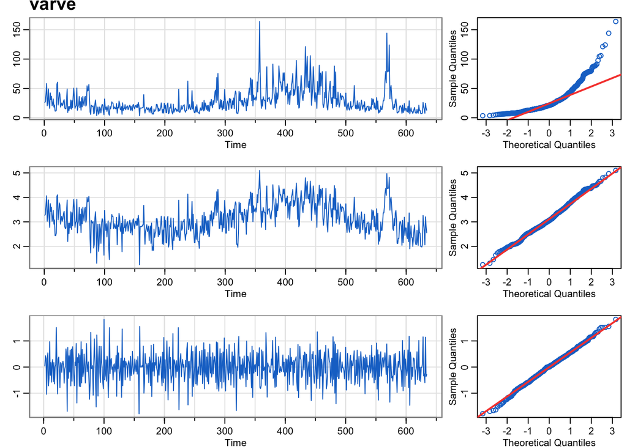

```r
layout(matrix(1:6,3), widths = c(2.5,1))
par(mgp = c(1.6,0.6,0), mar = c(2,2,0.5,0)+0.5)
tsplot(varve, main = "", ylab = "",col = 4, margin = 0)
mtext("varve", side = 3, line = 0.5, cex = 1.2, font = 2, adj = 0)
tsplot(log(varve), main = "", ylab = "", col = 4, margin = 0)
mtext("log(varve)", side = 3, line = 0.5, cex = 1.2, font = 2, adj = 9)
tsplot(diff(log(varve)), main = "", ylab = "", col = 4, margin = 0)
mtext("Diff(log(varve))", side = 3, line = 0.5, cex = 1.2, font = 2, adj = 9)
qqnorm(varve, main = "", col = 4); qqline(varve, col = 2, lwd = 2)
qqnorm(log(varve), main = "", col = 4); qqline(log(varve), col = 2, lwd = 2)
qqnorm(diff(log(varve)), main = "", col = 4); qqline(diff(log(varve)), col = 2, lwd = 2)
```

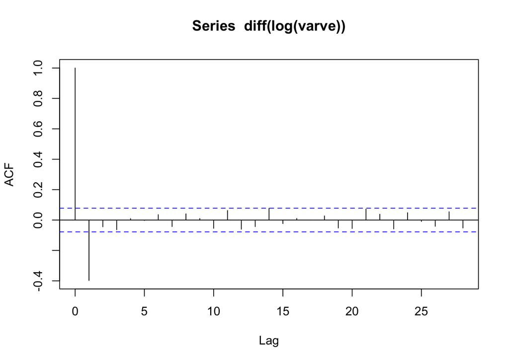

```r
acf(diff(log(varve)))
```

The third plot contains the difference of the log of the varves data. It can already bee seen a more uniform behavior throughout in the time series plot as well as in the qq plot. In addition the ACF for the difference is shown above and it shows that the difference produces a reasonably stationary series.